# Analyzing and Visualizing Data

The data used here to analyze and visualize is from the cleaned dataset produced from the twitter_enhanced_archive, image_predictions and api data obtained from twitter WeRateDogs.

```python
import pandas as pd
import numpy as np
import seaborn as sb
import matplotlib.pyplot as plt
%matplotlib inline
```

```python
df = pd.read_csv('twitter_archive_master.csv')
```

```python
df.shape
```

```
(1964, 16)
```

```python
df.head()
```

|  | tweet_id | timestamp | source | text | expanded_urls | name | growth_stage | rating | jpg_url | img_num | breed | confidence_level | retweet_count | favorite_count | followers_count | tweet_create_date |
| --- | --- | --- | --- | --- | --- | --- | --- | --- | --- | --- | --- | --- | --- | --- | --- | --- |
| 0 | 892420643555336193 | 2017-08-01 16:23:56 | Twitter for iPhone | This is Phineas. He's a mystical boy. Only eve... | https://twitter.com/dog_rates/status/892420643... | Phineas | None | 13.0 | https://pbs.twimg.com/media/DGKD1-bXoAAIAUK.jpg | 1 | NaN | 0.000000 | 7739 | 36368 | 8761748 | 2017-08-01 16:23:56 |
| 1 | 892177421306343426 | 2017-08-01 00:17:27 | Twitter for iPhone | This is Tilly. She's just checking pup on you.... | https://twitter.com/dog_rates/status/892177421... | Tilly | None | 13.0 | https://pbs.twimg.com/media/DGGmoV4XsAAUL6n.jpg | 1 | Chihuahua | 0.323581 | 5729 | 31325 | 8761748 | 2017-08-01 00:17:27 |
| 2 | 891815181378084864 | 2017-07-31 00:18:03 | Twitter for iPhone | This is Archie. He is a rare Norwegian Pouncin... | https://twitter.com/dog_rates/status/891815181... | Archie | None | 12.0 | https://pbs.twimg.com/media/DGBdLU1WsAANxJ9.jpg | 1 | Chihuahua | 0.716012 | 3790 | 23608 | 8761748 | 2017-07-31 00:18:03 |
| 3 | 891689557279858688 | 2017-07-30 15:58:51 | Twitter for iPhone | This is Darla. She commenced a snooze mid meal... | https://twitter.com/dog_rates/status/891689557... | Darla | None | 13.0 | https://pbs.twimg.com/media/DF_q7IAWsAEuuN8.jpg | 1 | Labrador_retriever | 0.168086 | 7903 | 39675 | 8761748 | 2017-07-30 15:58:51 |
| 4 | 891327558926688256 | 2017-07-29 16:00:24 | Twitter for iPhone | This is Franklin. He would like you to stop ca... | https://twitter.com/dog_rates/status/891327558... | Franklin | None | 12.0 | https://pbs.twimg.com/media/DF6hr6BUMAAzZgT.jpg | 2 | basset | 0.555712 | 8525 | 37875 | 8761748 | 2017-07-29 16:00:24 |

```python
df.info()
```

```
<class 'pandas.core.frame.DataFrame'>
RangeIndex: 1964 entries, 0 to 1963
Data columns (total 16 columns):
tweet_id             1964 non-null int64
timestamp            1964 non-null object
source               1964 non-null object
text                 1964 non-null object
expanded_urls        1964 non-null object
name                 1964 non-null object
growth_stage         1964 non-null object
rating               1964 non-null float64
jpg_url              1964 non-null object
img_num              1964 non-null int64
breed                1659 non-null object
confidence_level     1964 non-null float64
retweet_count        1964 non-null int64
favorite_count       1964 non-null int64
followers_count      1964 non-null int64
tweet_create_date    1964 non-null object
dtypes: float64(2), int64(5), object(9)
memory usage: 245.6+ KB
```

```python
df.jpg_url
```

```
0         https://pbs.twimg.com/media/DGKD1-bXoAAIAUK.jpg
1         https://pbs.twimg.com/media/DGGmoV4XsAAUL6n.jpg
2         https://pbs.twimg.com/media/DGBdLU1WsAANxJ9.jpg
3         https://pbs.twimg.com/media/DF_q7IAWsAEuuN8.jpg
4         https://pbs.twimg.com/media/DF6hr6BUMAAzZgT.jpg
5         https://pbs.twimg.com/media/DF3HwyEWsAABqE6.jpg
6         https://pbs.twimg.com/media/DF1eOmZXUAALUcq.jpg
7         https://pbs.twimg.com/media/DFyBahAVwAAhUTd.jpg
8         https://pbs.twimg.com/media/DFwUU__XcAEpyXI.jpg
9         https://pbs.twimg.com/media/DFrEyVuW0AAO3t9.jpg
10        https://pbs.twimg.com/media/DFnwSY4WAAAMliS.jpg
11        https://pbs.twimg.com/media/DFl99B1WsAITKsg.jpg
12        https://pbs.twimg.com/media/DFi579UWsAAatzw.jpg
13        https://pbs.twimg.com/media/DFihzFfXsAYGDPR.jpg
14        https://pbs.twimg.com/media/DFg_2PVW0AEHN3p.jpg
```

[output cut: 47 more lines]

# Converting columns to their appropriate datatypes

```python
df.tweet_id = df.tweet_id.astype(int)
df.timestamp = pd.to_datetime(df.timestamp)
df.tweet_create_date = pd.to_datetime(df.tweet_create_date)
```

```python
df.info()
```

```
<class 'pandas.core.frame.DataFrame'>
RangeIndex: 1964 entries, 0 to 1963
Data columns (total 16 columns):
tweet_id             1964 non-null int64
timestamp            1964 non-null datetime64[ns]
source               1964 non-null object
text                 1964 non-null object
expanded_urls        1964 non-null object
name                 1964 non-null object
growth_stage         1964 non-null object
rating               1964 non-null float64
jpg_url              1964 non-null object
img_num              1964 non-null int64
breed                1659 non-null object
confidence_level     1964 non-null float64
retweet_count        1964 non-null int64
favorite_count       1964 non-null int64
followers_count      1964 non-null int64
tweet_create_date    1964 non-null datetime64[ns]
dtypes: datetime64[ns](2), float64(2), int64(5), object(7)
memory usage: 245.6+ KB
```

# Observations

1) Correlation between retweet_count, followers_count, favorite_count

2) We can find the source from which users have tweeted the most

3) We can find what is the popular dog stage of our dog lovers

4) We can find which is the most popular breed of dog amongst our dog lovers

5) Using tweet_create_date we can see when or what time of day our dog lovers are most active at

```python
df_new = df[['growth_stage','breed','retweet_count','favorite_count']]
```

```python
df_new
```

# 1) Do our Dog lovers retweet most when they like a particular dog post?

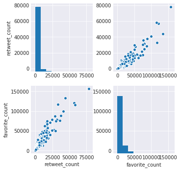

```python
sb.pairplot(df_new)
```

The above graph shows a positive correlation between retweet_count and favorite_count which basically means that when people like a particular dog post they tend to retweet it more than the others.

# 2) Most Common Source/ Through which medium do our dog lovers tweet the most?

```python
df.source.value_counts()
```

```
Twitter for iPhone    1926
Twitter Web Client      28
TweetDeck               10
Name: source, dtype: int64
```

# Majority of users seem to have tweeted using their iPhones

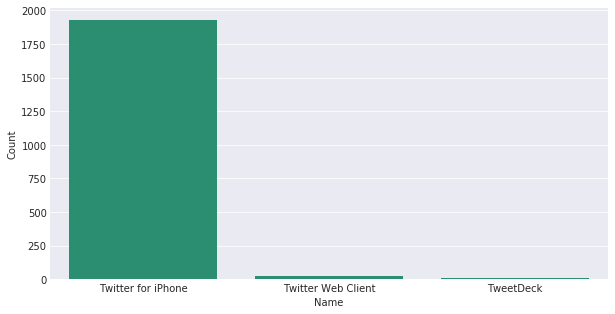

```python
plt.rcParams['figure.figsize'] = 10, 5
base_color = sb.color_palette('Dark2')[0]
sb.set_style('darkgrid')

sb.countplot(data=df, x='source', color=base_color);
plt.xlabel('Name');
plt.ylabel('Count');
```

# 3) Favorite dog stage among our dog lovers

```python
df.growth_stage.value_counts()
```

```
None       1662
pupper      209
doggo        63
puppo        22
floofer       8
Name: growth_stage, dtype: int64
```

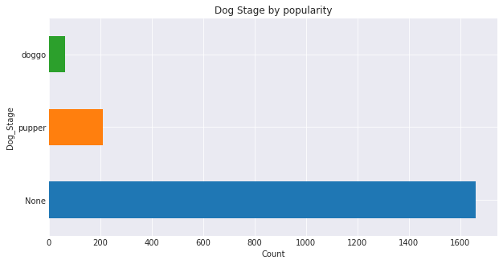

```python
stage = df.groupby('growth_stage').filter(lambda x: len(x) >= 25)
stage['growth_stage'].value_counts().plot(kind = 'barh')
plt.title('Dog Stage by popularity')
plt.xlabel('Count')
plt.ylabel('Dog_Stage');
```

The most popular dog stage is pupper

# 4) Most Popular Dog Breeds

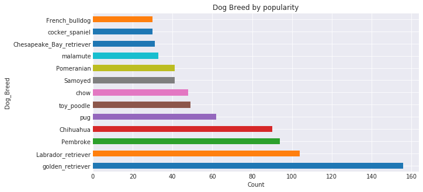

```python
breed = df.groupby('breed').filter(lambda x: len(x) >= 25)
breed['breed'].value_counts().plot(kind = 'barh')
plt.title('Dog Breed by popularity')
plt.xlabel('Count')
plt.ylabel('Dog_Breed');
```

# The most popualar dog breed seems to be Golden Retriever

# 5) Time of day our dog lovers are most active

```python
df['Hour'] = df.timestamp.dt.strftime('%H')
```

```python
df.Hour.value_counts()
```

```
01    275
00    248
02    209
16    189
03    164
17    157
23    109
18     98
04     95
15     90
19     81
20     75
21     69
22     67
05     26
14      8
06      3
13      1
Name: Hour, dtype: int64
```

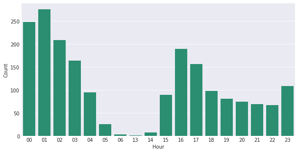

```python
plt.rcParams['figure.figsize'] = 10, 5
base_color = sb.color_palette('Dark2')[0]
sb.set_style('darkgrid')

sb.countplot(data=df, x='Hour', color=base_color);
plt.xlabel('Hour');
plt.ylabel('Count');
```

Our dog lovers seem to be less active between 6 am and 1pm. They are most active at 1am in the morning and pretty active during the course of the day.